# Cloud Optimization Strategy

## Stocking Shelves

- Assume you are the boss of Cloud, what should you do to maximize the profit?
- Remember! You need to be aware of your budget!
- Which product you want to produce the most?

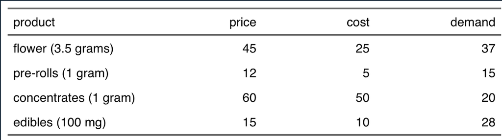

## Stocking Shelves Solution

```
Results of Linear Programming / Linear Optimization
(using lpSolve)

Objective function (Maximum): 1433100

Solution
    opt
1 12580
2 25500
3  3400
4 23800

Constraints
  actual dir   bvec free
1 850000  <= 850000    0
2 314500  == 314500    0
3 127500  == 127500    0
4 170000  == 170000    0
5 238000  == 238000    0
```

## Consumers: A Fickle Bag

- Is the previous situation reasonable in real life?
- Of course not! Demand varies all the time!
- Let’s assume concentrates will vary between 0.25 and 0,5.

```
   concentrates_demand max_revenue       X1    X2       X3       X4
1                 0.25     1426215 12370.33 25075 3626.667 23403.33
2                 0.26     1424838 12328.40 24990 3672.000 23324.00
3                 0.27     1423461 12286.47 24905 3717.333 23244.67
4                 0.28     1422084 12244.53 24820 3762.667 23165.33
5                 0.29     1420707 12202.60 24735 3808.000 23086.00
6                 0.30     1419330 12160.67 24650 3853.333 23006.67
7                 0.31     1417953 12118.73 24565 3898.667 22927.33
8                 0.32     1416576 12076.80 24480 3944.000 22848.00
9                 0.33     1415199 12034.87 24395 3989.333 22768.67
10                0.34     1413822 11992.93 24310 4034.667 22689.33
11                0.35     1412445 11951.00 24225 4080.000 22610.00
12                0.36     1411068 11909.07 24140 4125.333 22530.67
13                0.37     1409691 11867.13 24055 4170.667 22451.33
14                0.38     1408314 11825.20 23970 4216.000 22372.00
15                0.39     1406937 11783.27 23885 4261.333 22292.67
16                0.40     1405560 11741.33 23800 4306.667 22213.33
17                0.41     1404183 11699.40 23715 4352.000 22134.00
18                0.42     1402806 11657.47 23630 4397.333 22054.67
19                0.43     1401429 11615.53 23545 4442.667 21975.33
20                0.44     1400052 11573.60 23460 4488.000 21896.00
21                0.45     1398675 11531.67 23375 4533.333 21816.67
22                0.46     1397298 11489.73 23290 4578.667 21737.33
23                0.47     1395921 11447.80 23205 4624.000 21658.00
24                0.48     1394544 11405.87 23120 4669.333 21578.67
25                0.49     1393167 11363.93 23035 4714.667 21499.33
26                0.50     1391790 11322.00 22950 4760.000 21420.00
```

## Consumers: A Fickle Bag

- Let’s assume edibles will vary between 0.25 and 0.5.

```
   edibles_demand max_revenue       X1    X2        X3    X4
1            0.25     1405611 12705.80 25755 3434.0000 21250
2            0.26     1414774 12663.87 25670 3422.6667 22100
3            0.27     1423937 12621.93 25585 3411.3333 22950
4            0.28     1433100 12580.00 25500 3400.0000 23800
5            0.29     1434511 12538.07 25415 3259.4667 24650
6            0.30     1435922 12496.13 25330 3118.9333 25500
7            0.31     1437333 12454.20 25245 2978.4000 26350
8            0.32     1438744 12412.27 25160 2837.8667 27200
9            0.33     1440155 12370.33 25075 2697.3333 28050
10           0.34     1441566 12328.40 24990 2556.8000 28900
11           0.35     1442977 12286.47 24905 2416.2667 29750
12           0.36     1444388 12244.53 24820 2275.7333 30600
13           0.37     1445799 12202.60 24735 2135.2000 31450
14           0.38     1447210 12160.67 24650 1994.6667 32300
15           0.39     1448621 12118.73 24565 1854.1333 33150
16           0.40     1450032 12076.80 24480 1713.6000 34000
17           0.41     1451443 12034.87 24395 1573.0667 34850
18           0.42     1452854 11992.93 24310 1432.5333 35700
19           0.43     1454265 11951.00 24225 1292.0000 36550
20           0.44     1455676 11909.07 24140 1151.4667 37400
21           0.45     1457087 11867.13 24055 1010.9333 38250
22           0.46     1458498 11825.20 23970  870.4000 39100
23           0.47     1459909 11783.27 23885  729.8667 39950
24           0.48     1461320 11741.33 23800  589.3333 40800
25           0.49     1462731 11699.40 23715  448.8000 41650
26           0.50     1464142 11657.47 23630  308.2667 42500
```

## Moving Product

- Decide how to minimize the shipping cost from suppliers”.

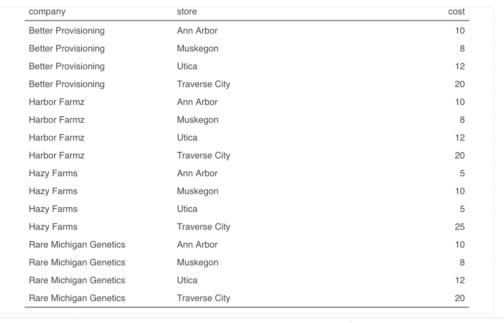

## Moving Product

- Total limited Suppy from Each Provider & Total Deamand for Each Store”.

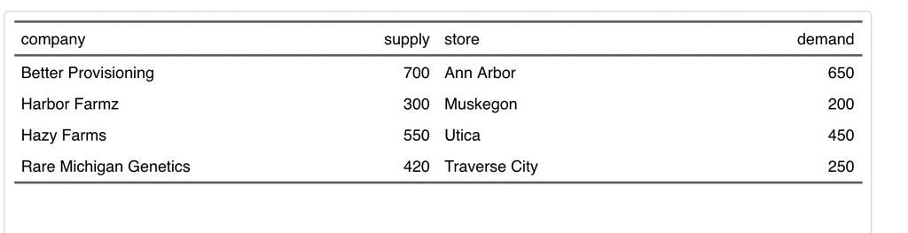

## Moving Product (Solution)

- Minimize Cost

```
Results of Linear Programming / Linear Optimization
(using lpSolve)

Objective function (Minimum): 14850

Solution
    opt
BA  250
BM  200
BU    0
BT  250
HA  300
HM    0
HU    0
HT    0
HZA 100
HZM   0
HZU 450
HZT   0
RA    0
RM    0
RU    0
RT    0

Constraints
  actual dir bvec free
1    700  <=  700    0
2    300  <=  300    0
3    550  <=  550    0
4      0  <=  420  420
5    650  ==  650    0
6    200  ==  200    0
7    450  ==  450    0
8    250  ==  250    0
```

## From sales to scales

- How many products approximately can Cloud make out in two years?
- A Random test for 2 years time

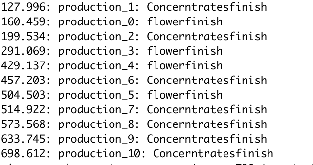

## From sales to scales

What’s the time length for the first finished product to be made out by testing 500 times?

```
[1] 111.8041
```

## From sales to scales

How to optimize and production?

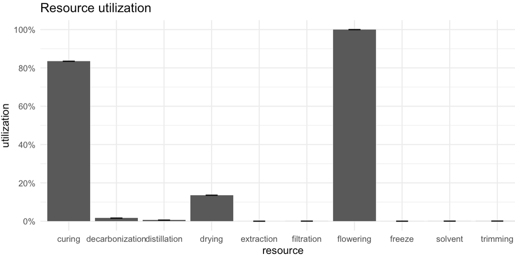

## From sales to scales

Double flowering and curring machine (Random for 2 years)

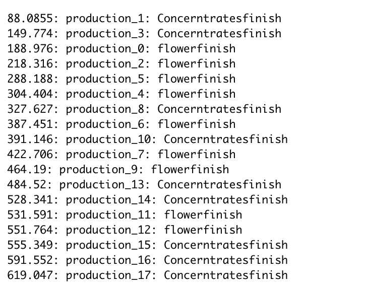

## Return On Investment

- Break down of yearly costs”.

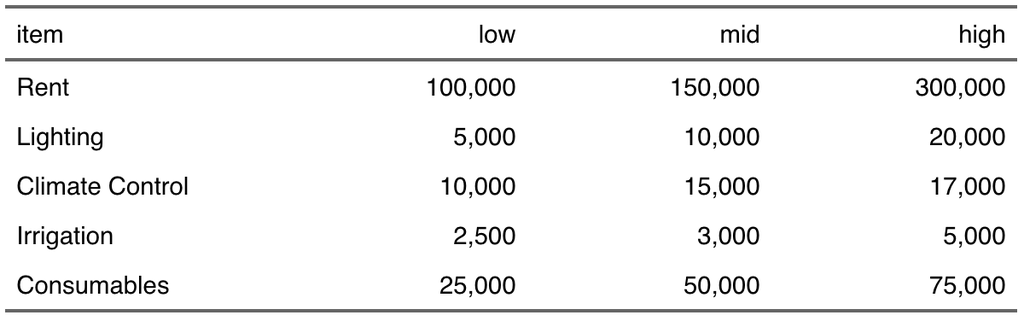

## Anticipated Profit

How much would Cloud likely make over the next 5 years?

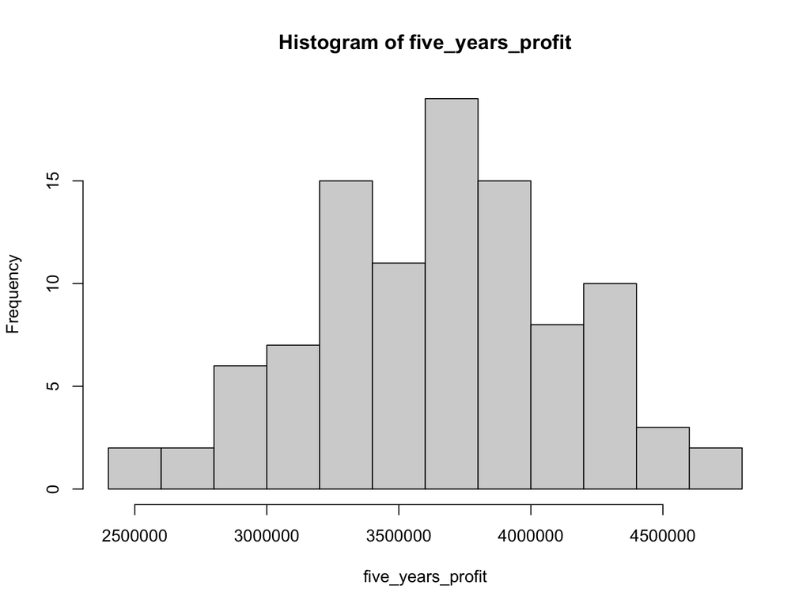